# Improvements by Instructor

Ken Field

Last compiled on 25 July 2023

IMPORTANT NOTE

This Rmd uses the deidentified results and is safe to share.

## Loading Results

Loading in the results without instructor information:

```r
NoDemographics <- read_delim("Deidentified Surveys/NoDemographics.tsv",
    delim = "\t", escape_double = FALSE,
    trim_ws = TRUE)
NoDemographicsQuestions <- read_delim("Deidentified Surveys/NoDemographicsQuestions.tsv",
    delim = "\t", escape_double = FALSE,
    trim_ws = TRUE)
```

## Improvement in learning elements

Comparing the responses to Pre10 and Post9:

```r
PreQ10 <- NoDemographics %>%
  select(Semester = Semester_pre, Instructor, starts_with("Q10")) %>%
  select(Semester, Instructor, ends_with("_pre"))
Q10Text <- NoDemographicsQuestions %>%
  filter(startsWith(value, "Q10")) %>%
  filter(endsWith(value, "_pre"))
Q10Text$Question[1]
```

```
## [1] "Please look over this inventory of elements that might be included in a course. For each element, give an estimate of your current level of ability before the course begins. Your current level of ability may be a result of courses in high school or college, or it may be a result of other exp…
```

```r
Q10TextClean <- Q10Text %>%
  mutate(Question = str_remove(Q10Text$Question, "Please look over this inventory of elements that might be included in a course. For each element, give an estimate of your current level of ability before the course begins. Your current level of ability may be a result of courses in high school or college, or it may be a result of other experiences such as jobs or special programs. If students are expected to do the following course elements, what would be their level of expertise\\? - "))
Q10TextClean$Question
```

```
##  [1] "A scripted lab or project in which the students know the expected outcome"
##  [2] "A lab or project in which only the instructor knows the outcome"
##  [3] "A lab or project where no one knows the outcome"
##  [4] "At least one project that is assigned and structured by the instructor"
##  [5] "A project in which students have some input into the research process and/or what is being studied"
##  [6] "A project entirely of student design"
##  [7] "Work individually"
##  [8] "Work as a whole class"
##  [9] "Work in small groups"
## [10] "Become responsible for a part of the project"
## [11] "Read primary scientific literature"
## [12] "Write a research proposal"
## [13] "Collect data"
## [14] "Analyze data"
## [15] "Present results orally"
## [16] "Present results in written papers or reports"
## [17] "Present posters"
## [18] "Critique the work of other students"
## [19] "Listen to lectures"
## [20] "Read a textbook"
## [21] "Work on problem sets"
## [22] "Take tests in class"
## [23] "Discuss reading materials in class"
## [24] "Maintain a lab notebook"
## [25] "Computer modeling"
```

```r
PostQ9 <- NoDemographics %>%
  select(starts_with("Q9")) %>%
  select(ends_with("_post"))

Q9Text <- NoDemographicsQuestions %>%
  filter(startsWith(value, "Q9")) %>%
  filter(endsWith(value, "_post"))
Q9Text$Question[1]
```

```
## [1] "Please rate how much learning you gained from each element you experienced in this course. The scale measuring your gain is from (no or very small gain) to (very large gain). Some elements may not have happened at all. If the item is not relevant or you prefer not to answer, please choose th…
```

```r
Q9TextClean <- Q9Text %>%
  mutate(Question = str_remove(Q9Text$Question, "Please rate how much learning you gained from each element you experienced in this course. The scale measuring your gain is from \\(no or very small gain\\) to \\(very large gain\\). Some elements may not have happened at all. If the item is not relevant or you prefer not to answer, please choose the \"\"not applicable\"\" option. If students were expected to do the following course elements, what would be their level of gained experience\\? - "))
Q9TextClean$Question
```

```
##  [1] "A scripted lab or project in which the students know the expected outcome"
##  [2] "A lab or project in which only the instructor knows the outcome"
##  [3] "A lab or project where no one knows the outcome"
##  [4] "At least one project that is assigned and structured by the instructor"
##  [5] "A project in which students have some input into the research process and/or what is being studied"
##  [6] "A project entirely of student design"
##  [7] "Work individually"
##  [8] "Work as a whole class"
##  [9] "Work in small groups"
## [10] "Become responsible for a part of the project"
## [11] "Read primary scientific literature"
## [12] "Write a research proposal"
## [13] "Collect data"
## [14] "Analyze data"
## [15] "Present results orally"
## [16] "Present results in written papers or reports"
## [17] "Present posters"
## [18] "Critique the work of other students"
## [19] "Listen to lectures"
## [20] "Read a textbook"
## [21] "Work on problem sets"
## [22] "Take tests in class"
## [23] "Discuss reading materials in class"
## [24] "Maintain a lab notebook"
## [25] "Computer modeling"
```

```r
Q9TextClean$Question == Q10TextClean$Question
```

```
##  [1] TRUE TRUE TRUE TRUE TRUE TRUE TRUE TRUE TRUE TRUE TRUE TRUE TRUE TRUE TRUE
## [16] TRUE TRUE TRUE TRUE TRUE TRUE TRUE TRUE TRUE TRUE
```

Now to compare the pre and post responses for those questions:

```r
MergedQ10 <- bind_cols(PreQ10, PostQ9)
head(MergedQ10)
```

```
## # A tibble: 6 × 52
##   Semester  Instructor Q10_1_pre Q10_2_pre Q10_3_pre Q10_4_pre Q10_5_pre
##   <chr>     <chr>      <chr>     <chr>     <chr>     <chr>     <chr>
## 1 Fall 2021 McGonagall Much      Some      None      Some      Extensive
## 2 Fall 2021 McGonagall Some      Much      None      Extensive Little
## 3 Fall 2021 McGonagall Some      Much      None      Much      Some
## 4 Fall 2021 McGonagall Little    Much      Little    Some      Some
## 5 Fall 2021 McGonagall Some      Some      Little    Much      Much
## 6 Fall 2021 McGonagall Some      Much      Little    Much      Some
## # ℹ 45 more variables: Q10_6_pre <chr>, Q10_7_pre <chr>, Q10_8_pre <chr>,
## #   Q10_9_pre <chr>, Q10_10_pre <chr>, Q10_11_pre <chr>, Q10_12_pre <chr>,
## #   Q10_13_pre <chr>, Q10_14_pre <chr>, Q10_15_pre <chr>, Q10_16_pre <chr>,
## #   Q10_17_pre <chr>, Q10_18_pre <chr>, Q10_19_pre <chr>, Q10_20_pre <chr>,
## #   Q10_21_pre <chr>, Q10_22_pre <chr>, Q10_23_pre <chr>, Q10_24_pre <chr>,
## #   Q10_25_pre <chr>, Q9_1_post <chr>, Q9_2_post <chr>, Q9_3_post <chr>,
## #   Q9_4_post <chr>, Q9_5_post <chr>, Q9_6_post <chr>, Q9_7_post <chr>, …
```

```r
Q10Factors <- MergedQ10 %>%
  select(starts_with("Q")) %>%
  mutate_all(funs(ordered(.,(levels = c("None", "Little",
                                       "Some", "Much", "Extensive")))))
Q10Clean <- MergedQ10 %>%
  select(-starts_with("Q")) %>%
  cbind(Q10Factors)
```

First let’s just look at the contingency tables to see if everything looks right.

```r
print("Rows represents pre-survey response, Columns represent post-survey response.")
```

```
## [1] "Rows represents pre-survey response, Columns represent post-survey response."
```

```r
print("First for All sections then for then by Instructor.")
```

```
## [1] "First for All sections then for then by Instructor."
```

```r
Q10TextClean$Question[1]
```

```
## [1] "A scripted lab or project in which the students know the expected outcome"
```

```r
table(Q10Clean$Q10_1_pre, Q10Clean$Q9_1_post)
```

```
##
##             None Little Some Much Extensive
##   None         0      1    0    0         0
##   Little       0      1    2    2         2
##   Some         0      2   10   15         6
##   Much         0      2    9   15        10
##   Extensive    0      1    0    2         0
```

```r
print("By Instructor")
```

```
## [1] "By Instructor"
```

```r
Q10TextClean$Question[1]
```

```
## [1] "A scripted lab or project in which the students know the expected outcome"
```

```r
table(Q10Clean$Q10_1_pre, Q10Clean$Q9_1_post, Q10Clean$Instructor)
```

```
## , ,  = Dumbledore
##
##
##             None Little Some Much Extensive
##   None         0      1    0    0         0
##   Little       0      0    1    0         1
##   Some         0      0    2    0         1
##   Much         0      0    0    2         5
##   Extensive    0      0    0    0         0
##
## , ,  = Hagrid
##
##
##             None Little Some Much Extensive
##   None         0      0    0    0         0
##   Little       0      0    1    1         0
##   Some         0      0    7    3         0
##   Much         0      0    0    2         0
##   Extensive    0      0    0    1         0
##
## , ,  = Lupin
##
##
##             None Little Some Much Extensive
##   None         0      0    0    0         0
##   Little       0      0    0    0         0
##   Some         0      0    0    1         2
##   Much         0      1    1    4         0
##   Extensive    0      0    0    1         0
##
## , ,  = McGonagall
##
##
##             None Little Some Much Extensive
##   None         0      0    0    0         0
##   Little       0      1    0    1         1
##   Some         0      1    1    9         1
##   Much         0      0    6    7         4
##   Extensive    0      1    0    0         0
##
## , ,  = Sinistra
##
##
##             None Little Some Much Extensive
##   None         0      0    0    0         0
##   Little       0      0    0    0         0
##   Some         0      1    0    2         2
##   Much         0      1    2    0         1
##   Extensive    0      0    0    0         0
```

Balloon Plot

On these plots, the answers on the x axis are the pre-survey results and on the y-axis are the post survey results. Responses above the “none” level indicate students who felt that they increased in this element.

The pre-survey questions were asked as: Please look over this inventory of elements that might be included in a course. For each element, give an estimate of your current level of ability before the course begins. Your current level of ability may be a result of courses in high school or college, or it may be a result of other experiences such as jobs or special programs. If students are expected to do the following course elements, what would be their level of expertise?

The post-survey questions were asked: Please rate how much learning you gained from each element you experienced in this course. The scale measuring your gain is from (no or very small gain) to (very large gain). Some elements may not have happened at all. If the item is not relevant or you prefer not to answer, please choose the “not applicable” option. If students were expected to do the following course elements, what would be their level of gained experience?

```r
colorcolumn <- rep.int(c(rep.int("None",5), rep.int("Little",5), rep.int("Some",5),
                 rep.int("Much",5), rep.int("Extensive", 5)), 5)

colorcolumn <- factor(colorcolumn,
                         levels = c("Extensive", "Much", "Some", "Little", "None"))
```

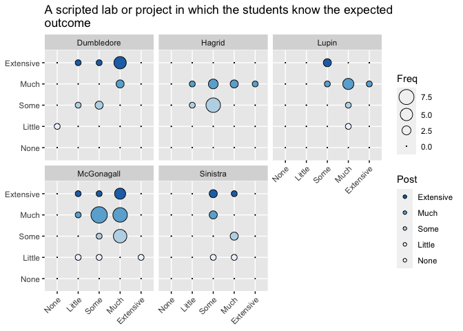

```r
Q10Clean %>%
  select(Q10_1_pre, Q9_1_post, Instructor) %>%
  table() %>%
  as.data.frame() %>%
  add_column(Post = colorcolumn) %>%
  ggballoonplot(x = "Q10_1_pre", y = "Q9_1_post", size = "Freq",
                ggtheme = theme_gray(), facet.by = "Instructor",
                fill = "Post", size.range = c(0, 8),
                title = paste(strwrap(Q10TextClean$Question[1], 72), collapse = "\n")) +
  fill_palette(c("#2171b5","#6baed6","#bdd7e7","#eff3ff","#FFFEFE"))
```

```r
# Using glm() to determine if post response depends on pre response or on instructor:
levels(as.factor(Q10Clean$Instructor))
```

```
## [1] "Dumbledore" "Hagrid"     "Lupin"      "McGonagall" "Sinistra"
```

```r
imp_model_Q10_1 <- glm(as.numeric(Q10Clean$Q9_1_post) ~
                      as.numeric(Q10Clean$Q10_1_pre) + Q10Clean$Instructor)
summary(imp_model_Q10_1)
```

```
##
## Call:
## glm(formula = as.numeric(Q10Clean$Q9_1_post) ~ as.numeric(Q10Clean$Q10_1_pre) +
##     Q10Clean$Instructor)
##
## Deviance Residuals:
##     Min       1Q   Median       3Q      Max
## -1.9726  -0.5200   0.1493   0.5496   1.3931
##
## Coefficients:
##                                Estimate Std. Error t value Pr(>|t|)
## (Intercept)                      3.7600     0.5098   7.375 1.95e-10 ***
## as.numeric(Q10Clean$Q10_1_pre)   0.1219     0.1379   0.884   0.3795
## Q10Clean$InstructorHagrid       -0.6753     0.3392  -1.991   0.0502 .
## Q10Clean$InstructorLupin        -0.3232     0.3844  -0.841   0.4031
## Q10Clean$InstructorMcGonagall   -0.3969     0.2950  -1.346   0.1826
## Q10Clean$InstructorSinistra     -0.5132     0.3890  -1.319   0.1911
## ---
## Signif. codes:  0 '***' 0.001 '**' 0.01 '*' 0.05 '.' 0.1 ' ' 1
##
## (Dispersion parameter for gaussian family taken to be 0.8002052)
##
##     Null deviance: 63.388  on 79  degrees of freedom
## Residual deviance: 59.215  on 74  degrees of freedom
##   (5 observations deleted due to missingness)
## AIC: 216.96
##
## Number of Fisher Scoring iterations: 2
```

```r
# NA's are going to cause problems with the model selection, so I will prepare to remove them
Q10Clean_withNA <- Q10Clean


step_imp_model_Q10_1 <- stepAIC(imp_model_Q10_1, direction = "backward")
```

```
## Start:  AIC=216.96
## as.numeric(Q10Clean$Q9_1_post) ~ as.numeric(Q10Clean$Q10_1_pre) +
##     Q10Clean$Instructor
##
##                                  Df Deviance    AIC
## - Q10Clean$Instructor             4   62.591 213.40
## - as.numeric(Q10Clean$Q10_1_pre)  1   59.841 215.80
## <none>                                59.215 216.96
##
## Step:  AIC=213.4
## as.numeric(Q10Clean$Q9_1_post) ~ as.numeric(Q10Clean$Q10_1_pre)
##
##                                  Df Deviance    AIC
## - as.numeric(Q10Clean$Q10_1_pre)  1   63.388 212.41
## <none>                                62.591 213.40
##
## Step:  AIC=212.41
## as.numeric(Q10Clean$Q9_1_post) ~ 1
```

```r
summary(step_imp_model_Q10_1)
```

```
##
## Call:
## glm(formula = as.numeric(Q10Clean$Q9_1_post) ~ 1)
##
## Deviance Residuals:
##     Min       1Q   Median       3Q      Max
## -1.7875  -0.7875   0.2125   0.2125   1.2125
##
## Coefficients:
##             Estimate Std. Error t value Pr(>|t|)
## (Intercept)   3.7875     0.1001   37.82   <2e-16 ***
## ---
## Signif. codes:  0 '***' 0.001 '**' 0.01 '*' 0.05 '.' 0.1 ' ' 1
##
## (Dispersion parameter for gaussian family taken to be 0.8023734)
##
##     Null deviance: 63.388  on 79  degrees of freedom
## Residual deviance: 63.388  on 79  degrees of freedom
##   (5 observations deleted due to missingness)
## AIC: 212.41
##
## Number of Fisher Scoring iterations: 2
```

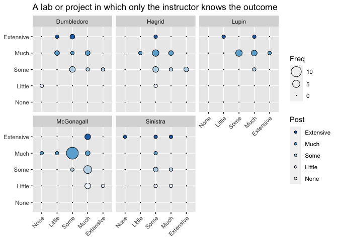

```r
Q10Clean_withNA %>%
  select(Q10_2_pre, Q9_2_post, Instructor) %>%
  table() %>%
  as.data.frame() %>%
  add_column(Post = colorcolumn) %>%
  ggballoonplot(x = "Q10_2_pre", y = "Q9_2_post", size = "Freq",
                ggtheme = theme_gray(), facet.by = "Instructor",
                fill = "Post", size.range = c(0, 8),
                title = paste(strwrap(Q10TextClean$Question[2], 72), collapse = "\n")) +
  fill_palette(c("#2171b5","#6baed6","#bdd7e7","#eff3ff","#FFFEFE"))
```

```r
# Using glm() to determine if post response depends on pre response or on instructor:
levels(as.factor(Q10Clean$Instructor))
```

```
## [1] "Dumbledore" "Hagrid"     "Lupin"      "McGonagall" "Sinistra"
```

```r
imp_model_Q10_2 <- glm(as.numeric(Q10Clean$Q9_2_post) ~
                      as.numeric(Q10Clean$Q10_2_pre) + Q10Clean$Instructor)
summary(imp_model_Q10_2)
```

```
##
## Call:
## glm(formula = as.numeric(Q10Clean$Q9_2_post) ~ as.numeric(Q10Clean$Q10_2_pre) +
##     Q10Clean$Instructor)
##
## Deviance Residuals:
##      Min        1Q    Median        3Q       Max
## -2.27590  -0.45827   0.03673   0.35434   1.69405
##
## Coefficients:
##                                Estimate Std. Error t value Pr(>|t|)
## (Intercept)                     4.55670    0.39954  11.405   <2e-16 ***
## as.numeric(Q10Clean$Q10_2_pre) -0.28081    0.11114  -2.527   0.0136 *
## Q10Clean$InstructorHagrid      -0.06863    0.30932  -0.222   0.8250
## Q10Clean$InstructorLupin        0.52979    0.33738   1.570   0.1206
## Q10Clean$InstructorMcGonagall   0.02479    0.26779   0.093   0.9265
## Q10Clean$InstructorSinistra    -0.12753    0.35215  -0.362   0.7183
## ---
## Signif. codes:  0 '***' 0.001 '**' 0.01 '*' 0.05 '.' 0.1 ' ' 1
##
## (Dispersion parameter for gaussian family taken to be 0.6785345)
##
##     Null deviance: 57.654  on 80  degrees of freedom
## Residual deviance: 50.890  on 75  degrees of freedom
##   (4 observations deleted due to missingness)
## AIC: 206.22
##
## Number of Fisher Scoring iterations: 2
```

```r
step_imp_model_Q10_2 <- stepAIC(imp_model_Q10_2, direction = "backward")
```

```
## Start:  AIC=206.22
## as.numeric(Q10Clean$Q9_2_post) ~ as.numeric(Q10Clean$Q10_2_pre) +
##     Q10Clean$Instructor
##
##                                  Df Deviance    AIC
## - Q10Clean$Instructor             4   53.930 202.92
## <none>                                50.890 206.22
## - as.numeric(Q10Clean$Q10_2_pre)  1   55.222 210.84
##
## Step:  AIC=202.92
## as.numeric(Q10Clean$Q9_2_post) ~ as.numeric(Q10Clean$Q10_2_pre)
##
##                                  Df Deviance    AIC
## <none>                                53.930 202.92
## - as.numeric(Q10Clean$Q10_2_pre)  1   57.654 206.33
```